# *Import library in Python*

1. NumPy library which provides objects for multi-dimensional arrays.
2. Pandas provides in-memory 2d table object called Dataframe
3. Matplotlib for visualization
4. seaborn for 2d visualization
5. Plotly for interactive visualization

```python
!pip install plotly_express
import numpy as np
import pandas as pd
import matplotlib.pyplot as plt
import plotly_express as px
import seaborn as sns
```

```python
df=pd.read_csv('heart.csv') # Read the dataset
```

# *Data pre-processing*

**1.** *Missing data:* Missing data can be found when it is not continuously created or due to technical issues in the application (IOT system).

**2.** *Noisy data:* This type of data is also called outliners, this can occur due to human errors (human manually gathering the data) or some technical problem of the device at the time of collection of data.

**3.** *Inconsistent data:* This type of data might be collected due to human errors (mistakes with the name or values) or duplication of data.

```python
df.head(10)
```

|  | age | sex | cp | trestbps | chol | fbs | restecg | thalach | exang | oldpeak | slope | ca | thal | target |
| --- | --- | --- | --- | --- | --- | --- | --- | --- | --- | --- | --- | --- | --- | --- |
| 0 | 63 | 1 | 3 | 145 | 233 | 1 | 0 | 150 | 0 | 2.3 | 0 | 0 | 1 | 1 |
| 1 | 37 | 1 | 2 | 130 | 250 | 0 | 1 | 187 | 0 | 3.5 | 0 | 0 | 2 | 1 |
| 2 | 41 | 0 | 1 | 130 | 204 | 0 | 0 | 172 | 0 | 1.4 | 2 | 0 | 2 | 1 |
| 3 | 56 | 1 | 1 | 120 | 236 | 0 | 1 | 178 | 0 | 0.8 | 2 | 0 | 2 | 1 |
| 4 | 57 | 0 | 0 | 120 | 354 | 0 | 1 | 163 | 1 | 0.6 | 2 | 0 | 2 | 1 |
| 5 | 57 | 1 | 0 | 140 | 192 | 0 | 1 | 148 | 0 | 0.4 | 1 | 0 | 1 | 1 |
| 6 | 56 | 0 | 1 | 140 | 294 | 0 | 0 | 153 | 0 | 1.3 | 1 | 0 | 2 | 1 |
| 7 | 44 | 1 | 1 | 120 | 263 | 0 | 1 | 173 | 0 | 0.0 | 2 | 0 | 3 | 1 |
| 8 | 52 | 1 | 2 | 172 | 199 | 1 | 1 | 162 | 0 | 0.5 | 2 | 0 | 3 | 1 |
| 9 | 57 | 1 | 2 | 150 | 168 | 0 | 1 | 174 | 0 | 1.6 | 2 | 0 | 2 | 1 |

# *Data contains:*

- age - age in years
- sex - (1 = male; 0 = female)
- cp - chest pain type
- trestbps - resting blood pressure (in mm Hg on admission to the hospital)
- chol - serum cholestoral in mg/dl
- fbs - (fasting blood sugar > 120 mg/dl) (1 = true; 0 = false)
- restecg - resting electrocardiographic results
- thalach - maximum heart rate achieved
- exang - exercise induced angina (1 = yes; 0 = no)
- oldpeak - ST depression induced by exercise relative to rest
- slope - the slope of the peak exercise ST segment
- ca - number of major vessels (0-3) colored by flourosopy
- thal - 3 = normal; 6 = fixed defect; 7 = reversable defect
- target - have disease or not (1=yes, 0=no)

```python
df.isnull().sum()
```

```
age         0
sex         0
cp          0
trestbps    0
chol        0
fbs         0
restecg     0
thalach     0
exang       0
oldpeak     0
slope       0
ca          0
thal        0
target      0
dtype: int64
```

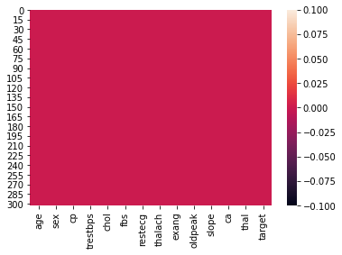

```python
sns.heatmap(df.isnull(),cbar=True)
# Zero null value is present in this dataset
```

```python
df.describe().T
# Statistical Report Of the Data
```

|  | count | mean | std | min | 25% | 50% | 75% | max |
| --- | --- | --- | --- | --- | --- | --- | --- | --- |
| age | 303.0 | 54.366337 | 9.082101 | 29.0 | 47.5 | 55.0 | 61.0 | 77.0 |
| sex | 303.0 | 0.683168 | 0.466011 | 0.0 | 0.0 | 1.0 | 1.0 | 1.0 |
| cp | 303.0 | 0.966997 | 1.032052 | 0.0 | 0.0 | 1.0 | 2.0 | 3.0 |
| trestbps | 303.0 | 131.623762 | 17.538143 | 94.0 | 120.0 | 130.0 | 140.0 | 200.0 |
| chol | 303.0 | 246.264026 | 51.830751 | 126.0 | 211.0 | 240.0 | 274.5 | 564.0 |
| fbs | 303.0 | 0.148515 | 0.356198 | 0.0 | 0.0 | 0.0 | 0.0 | 1.0 |
| restecg | 303.0 | 0.528053 | 0.525860 | 0.0 | 0.0 | 1.0 | 1.0 | 2.0 |
| thalach | 303.0 | 149.646865 | 22.905161 | 71.0 | 133.5 | 153.0 | 166.0 | 202.0 |
| exang | 303.0 | 0.326733 | 0.469794 | 0.0 | 0.0 | 0.0 | 1.0 | 1.0 |
| oldpeak | 303.0 | 1.039604 | 1.161075 | 0.0 | 0.0 | 0.8 | 1.6 | 6.2 |
| slope | 303.0 | 1.399340 | 0.616226 | 0.0 | 1.0 | 1.0 | 2.0 | 2.0 |
| ca | 303.0 | 0.729373 | 1.022606 | 0.0 | 0.0 | 0.0 | 1.0 | 4.0 |
| thal | 303.0 | 2.313531 | 0.612277 | 0.0 | 2.0 | 2.0 | 3.0 | 3.0 |
| target | 303.0 | 0.544554 | 0.498835 | 0.0 | 0.0 | 1.0 | 1.0 | 1.0 |

```python
df.shape
# 303 rows and 14 columns in dataset
```

```
(303, 14)
```

Find Out Outliers In this Data set

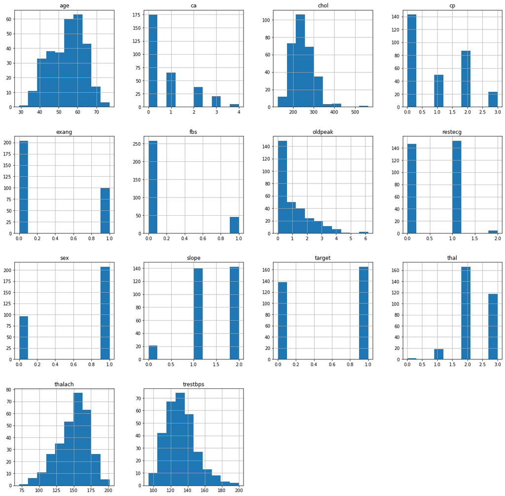

```python
print(df.hist(figsize=(20,20)))
```

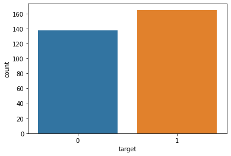

```python
sns.countplot(x=df['target'])
##  Here we Clearly seen the dataset is balanced
```

```python
df.columns
```

```
Index(['age', 'sex', 'cp', 'trestbps', 'chol', 'fbs', 'restecg', 'thalach',
       'exang', 'oldpeak', 'slope', 'ca', 'thal', 'target'],
      dtype='object')
```

# *In statistics, an outlier is an observation point that is distant from other observations.*

There are two types of analysis we will follow to find the outliers- Uni-variate(one variable outlier analysis) and Multi-variate(two or more variable outlier analysis).

# *Discover outliers with visualization tools*

**1. Box plot:** In descriptive statistics, a box plot is a method for graphically depicting groups of numerical data through their quartiles. Box plots may also have lines extending vertically from the boxes (whiskers) indicating variability outside the upper and lower quartiles, hence the terms box-and-whisker plot and box-and-whisker diagram. Outliers may be plotted as individual points.

```python
px.box(df, y='chol')
```

[interactive chart not shown]

```python
px.box(df, y='age')
```

[interactive chart not shown]

```python
px.box(df, y='trestbps')
```

[interactive chart not shown]

```python
px.box(df, y='thalach')
```

[interactive chart not shown]

# *Now, how do we deal with outliers? Here are four approaches:*

*1. Drop the outlier records:* In the case of Bill Gates, or another true outlier, sometimes it’s best to completely remove that record from your dataset to keep that person or event from skewing your analysis.

*2. Cap your outliers data:* Another way to handle true outliers is to cap them. For example, if you’re using income, you might find that people above a certain income level behave in the same way as those with a lower income. In this case, you can cap the income value at a level that keeps that intact.

*3. Assign a new value:* If an outlier seems to be due to a mistake in your data, you try imputing a value. Common imputation methods include using the mean of a variable or utilizing a regression model to predict the missing value.

*4. Try a transformation:* A different approach to true outliers could be to try creating a transformation of the data rather than using the data itself. For example, try creating a percentile version of your original field and working with that new field instead.

# *Just how much an outlier affects your analysis depends, not surprisingly, on a few factors. One factor is dataset size. In a large dataset, each individual point carries less weight, so an outlier is less worrisome than the same data point would be in a smaller dataset. Another consideration is “how much” of an outlier a point might be – just how far out of line with the rest of your dataset a single point is. A point that is ten times as large as your upper boundary will do more damage than a point that is twice as large.*

```python
df.loc[df['thalach']==71,:]
```

|  | age | sex | cp | trestbps | chol | fbs | restecg | thalach | exang | oldpeak | slope | ca | thal | target |
| --- | --- | --- | --- | --- | --- | --- | --- | --- | --- | --- | --- | --- | --- | --- |
| 272 | 67 | 1 | 0 | 120 | 237 | 0 | 1 | 71 | 0 | 1.0 | 1 | 0 | 2 | 0 |

```python
df.drop(df.index[272],inplace=True)
```

```python
px.box(df, y='thalach')
```

[interactive chart not shown]

```python
df.loc[(df['trestbps']>=172),'trestbps']=130
```

```python
px.box(df, y='trestbps')
```

[interactive chart not shown]

```python
df.shape
```

```
(302, 14)
```

# *Data Exploration*

Having a clean dataset in hand, we need to understand the data, summarize its characteristics, and visualize it. Understanding the data is an iterative process between the data science team and the experts from the business side. It can help both sides to identify and construct important features, and later to build suitable machine learning models.

An essential part of data exploration is data transformation

# *Some commonly used plots for EDA are:*

*1. Histograms:* to check the distribution of a specific variable

*2. Scatter plots:* to check the dependency between two variables

*3. Maps:* to show distribution of a variable on a regional or world map  
*4. Feature correlation plot (heatmap):* to understand the dependencies between multiple variables

# In conclusion, Exploratory Data Analysis is a vital step in a data science project. The main pillars of EDA are data cleaning, data preparation, data exploration, and data visualization. There are various exploratory tools (Python and R), and enterprise applications (Power BI, SAP Cloud Analytics, Tableau, etc.) to perform EDA, each of them offering a unique set of tools.

```python
df.info() # All the features are Numerical value
```

```
<class 'pandas.core.frame.DataFrame'>
Int64Index: 302 entries, 0 to 302
Data columns (total 14 columns):
 #   Column    Non-Null Count  Dtype
---  ------    --------------  -----
 0   age       302 non-null    int64
 1   sex       302 non-null    int64
 2   cp        302 non-null    int64
 3   trestbps  302 non-null    int64
 4   chol      302 non-null    int64
 5   fbs       302 non-null    int64
 6   restecg   302 non-null    int64
 7   thalach   302 non-null    int64
 8   exang     302 non-null    int64
 9   oldpeak   302 non-null    float64
 10  slope     302 non-null    int64
 11  ca        302 non-null    int64
 12  thal      302 non-null    int64
 13  target    302 non-null    int64
dtypes: float64(1), int64(13)
memory usage: 35.4 KB
```

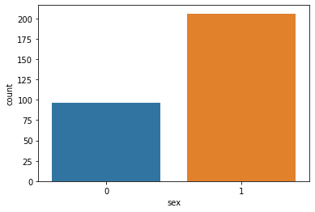

```python
sns.countplot(df['sex'])
```

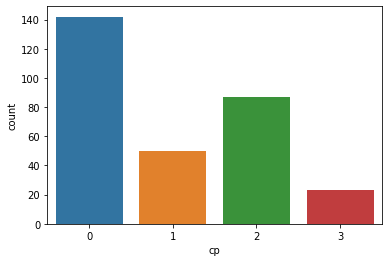

```python
sns.countplot(df['cp'])
```

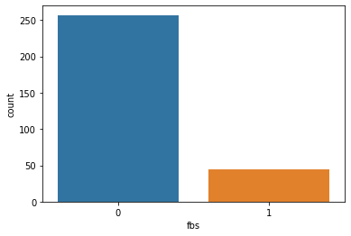

```python
sns.countplot(df['fbs'])
```

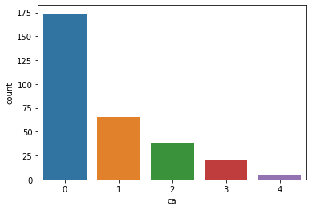

```python
sns.countplot(df['ca'])
```

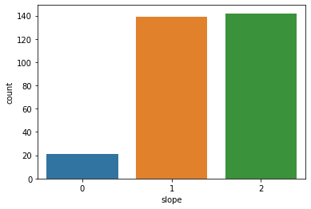

```python
sns.countplot(df['slope'])
```

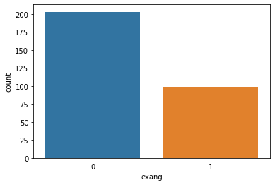

```python
sns.countplot(df['exang'])
```

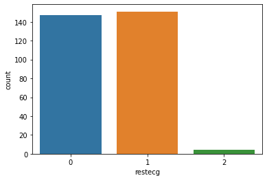

```python
sns.countplot(df['restecg'])
```

# *Feature Scaling:*

Feature Scaling is a technique to standardize the independent features present in the data in a fixed range. It is performed during the data pre-processing.

# **Machine learning algorithm just sees number — if there is a vast difference in the range say few ranging in thousands and few ranging in the tens, and it makes the underlying assumption that higher ranging numbers have superiority of some sort. So these more significant number starts playing a more decisive role while training the model.**

```python
from sklearn.preprocessing import MinMaxScaler
```

```python
 scaler = MinMaxScaler()
```

```python
scaled=scaler.fit_transform(df.values)
```

```python
df1=pd.DataFrame(scaled, columns=df.columns)
```

# *Build Model*

1. Logistic Reggresion
2. Decision Tree
3. Random Forest
4. KNN
5. SVM

```python
from sklearn.model_selection import train_test_split
```

Split data for training and testing

```python
X=df1.iloc[:,:-1] # Indepandant Features or Features
Y=df1.iloc[:,-1] # Depandant Feature or label
```

# *Feature Selection:*

Feature Selection is one of the core concepts in machine learning which hugely impacts the performance of your model.

```
[0.07032125 0.05564125 0.11433372 0.06111829 0.05837329 0.01947252
 0.03651428 0.0822658  0.10129302 0.08392238 0.07937222 0.12924588
 0.10812609]
```

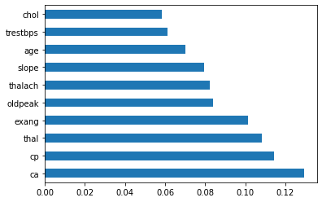

```python
from sklearn.ensemble import ExtraTreesClassifier
import matplotlib.pyplot as plt
model = ExtraTreesClassifier()
model.fit(X,Y)
print(model.feature_importances_) #use inbuilt class feature_importances of tree based classifiers
#plot graph of feature importances for better visualization
feat_importances = pd.Series(model.feature_importances_, index=X.columns)
feat_importances.nlargest(10).plot(kind='barh')
plt.show()
```

```python
df1.drop(['chol','trestbps','age','slope'],axis=1, inplace=True)
```

```python
df1.shape
```

```
(302, 10)
```

```python
X=df1.iloc[:,:-1] # Indepandant Features or Features
Y=df1.iloc[:,-1] # Depandant Feature or label
```

```python
x_train,x_test,y_train, y_test=train_test_split(X,Y, test_size=0.25)
```

# *Logistic Reggresion*

```python
from sklearn.linear_model import LogisticRegression
model1=LogisticRegression()
model1.fit(x_train,y_train)
```

```
LogisticRegression(C=1.0, class_weight=None, dual=False, fit_intercept=True,
                   intercept_scaling=1, l1_ratio=None, max_iter=100,
                   multi_class='auto', n_jobs=None, penalty='l2',
                   random_state=None, solver='lbfgs', tol=0.0001, verbose=0,
                   warm_start=False)
```

```python
y_pred=model1.predict(x_test)
```

```python
from sklearn.metrics import confusion_matrix, classification_report, accuracy_score
```

```python
accuracy_score(y_test,y_pred)
```

```
0.8421052631578947
```

```python
confusion_matrix(y_test,y_pred)
```

```
array([[21,  9],
       [ 3, 43]])
```

```python
print(classification_report(y_test, y_pred))
```

```
              precision    recall  f1-score   support

         0.0       0.88      0.70      0.78        30
         1.0       0.83      0.93      0.88        46

    accuracy                           0.84        76
   macro avg       0.85      0.82      0.83        76
weighted avg       0.85      0.84      0.84        76
```

# DEcision Tree

```python
from sklearn.tree import DecisionTreeClassifier
model2=DecisionTreeClassifier()
model2.fit(x_train,y_train)
```

```
DecisionTreeClassifier(ccp_alpha=0.0, class_weight=None, criterion='gini',
                       max_depth=None, max_features=None, max_leaf_nodes=None,
                       min_impurity_decrease=0.0, min_impurity_split=None,
                       min_samples_leaf=1, min_samples_split=2,
                       min_weight_fraction_leaf=0.0, presort='deprecated',
                       random_state=None, splitter='best')
```

```python
y_pred2=model2.predict(x_test)
```

```python
confusion_matrix(y_test,y_pred2)
```

```
array([[21,  9],
       [ 8, 38]])
```

```python
accuracy_score(y_test,y_pred2)
```

```
0.7763157894736842
```

```python
print(classification_report(y_test,y_pred2))
```

```
              precision    recall  f1-score   support

         0.0       0.72      0.70      0.71        30
         1.0       0.81      0.83      0.82        46

    accuracy                           0.78        76
   macro avg       0.77      0.76      0.76        76
weighted avg       0.78      0.78      0.78        76
```

# Random Forest

```python
from sklearn.ensemble import RandomForestClassifier
model3=RandomForestClassifier(n_estimators=150)
model3.fit(x_train,y_train)
```

```
RandomForestClassifier(bootstrap=True, ccp_alpha=0.0, class_weight=None,
                       criterion='gini', max_depth=None, max_features='auto',
                       max_leaf_nodes=None, max_samples=None,
                       min_impurity_decrease=0.0, min_impurity_split=None,
                       min_samples_leaf=1, min_samples_split=2,
                       min_weight_fraction_leaf=0.0, n_estimators=150,
                       n_jobs=None, oob_score=False, random_state=None,
                       verbose=0, warm_start=False)
```

```python
y_pred3=model3.predict(x_test)
```

```python
confusion_matrix(y_test,y_pred3)
```

```
array([[23,  7],
       [ 2, 44]])
```

```python
accuracy_score(y_test,y_pred3)
```

```
0.881578947368421
```

```python
print(classification_report(y_test,y_pred3))
```

```
              precision    recall  f1-score   support

         0.0       0.92      0.77      0.84        30
         1.0       0.86      0.96      0.91        46

    accuracy                           0.88        76
   macro avg       0.89      0.86      0.87        76
weighted avg       0.89      0.88      0.88        76
```

# KNN

```python
from sklearn.neighbors import KNeighborsClassifier
model4=KNeighborsClassifier(n_neighbors=10)
model4.fit(x_train,y_train)
```

```
KNeighborsClassifier(algorithm='auto', leaf_size=30, metric='minkowski',
                     metric_params=None, n_jobs=None, n_neighbors=10, p=2,
                     weights='uniform')
```

```python
y_pred4=model4.predict(x_test)
```

```python
accuracy_score(y_test,y_pred4)
```

```
0.75
```

```python
confusion_matrix(y_test,y_pred4)
```

```
array([[20, 10],
       [ 9, 37]])
```

```python
print(classification_report(y_test,y_pred4))
```

```
              precision    recall  f1-score   support

         0.0       0.69      0.67      0.68        30
         1.0       0.79      0.80      0.80        46

    accuracy                           0.75        76
   macro avg       0.74      0.74      0.74        76
weighted avg       0.75      0.75      0.75        76
```

```python
from sklearn.svm import SVC
model5=SVC(kernel='linear')
model5.fit(x_train,y_train)
```

```
SVC(C=1.0, break_ties=False, cache_size=200, class_weight=None, coef0=0.0,
    decision_function_shape='ovr', degree=3, gamma='scale', kernel='linear',
    max_iter=-1, probability=False, random_state=None, shrinking=True,
    tol=0.001, verbose=False)
```

```python
y_pred5=model5.predict(x_test)
```

```python
accuracy_score(y_test,y_pred5)
```

```
0.8421052631578947
```

```python
confusion_matrix(y_test,y_pred5)
```

```
array([[21,  9],
       [ 3, 43]])
```

```python
print(classification_report(y_test,y_pred5))
```

```
              precision    recall  f1-score   support

         0.0       0.88      0.70      0.78        30
         1.0       0.83      0.93      0.88        46

    accuracy                           0.84        76
   macro avg       0.85      0.82      0.83        76
weighted avg       0.85      0.84      0.84        76
```

# **Model Selection**

```python
from sklearn.model_selection import cross_val_score
```

```python
print(cross_val_score(model1, X, Y, cv=5).mean())
print(cross_val_score(model2, X, Y, cv=5).mean())
print(cross_val_score(model3, X, Y, cv=5).mean())
print(cross_val_score(model4, X, Y, cv=5).mean())
print(cross_val_score(model5, X, Y, cv=5).mean())
```

```
0.830928961748634
0.761584699453552
0.8110382513661202
0.7483060109289618
0.8242622950819671
```

```python
from sklearn.naive_bayes import GaussianNB
model6=GaussianNB()
model6.fit(x_train,y_train)
y_pred6=model6.predict(x_test)
```

```python
accuracy_score(y_test,y_pred6)
```

```
0.8552631578947368
```

```python
print(cross_val_score(model6, X, Y, cv=5).mean())
```

```
0.8109289617486338
```

# **Tuning the hyper-parameters:**

```python
param_grid = {'C': [0.1,1, 10, 100], 'gamma': [1,0.1,0.01,0.001],'kernel': ['rbf', 'poly', 'sigmoid']}
```

```python
from sklearn.model_selection import GridSearchCV
```

```python
grid = GridSearchCV(SVC(),param_grid,refit=True,verbose=2)
grid.fit(x_train,y_train)
```

[output not shown]

[output cut: 19 more lines]

[output not shown]

```
[Parallel(n_jobs=1)]: Using backend SequentialBackend with 1 concurrent workers.
[Parallel(n_jobs=1)]: Done   1 out of   1 | elapsed:    0.0s remaining:    0.0s
```

[output not shown]

[output cut: 352 more lines]

[output not shown]

```
[Parallel(n_jobs=1)]: Done 240 out of 240 | elapsed:    1.3s finished
```

```
GridSearchCV(cv=None, error_score=nan,
             estimator=SVC(C=1.0, break_ties=False, cache_size=200,
                           class_weight=None, coef0=0.0,
                           decision_function_shape='ovr', degree=3,
                           gamma='scale', kernel='rbf', max_iter=-1,
                           probability=False, random_state=None, shrinking=True,
                           tol=0.001, verbose=False),
             iid='deprecated', n_jobs=None,
             param_grid={'C': [0.1, 1, 10, 100], 'gamma': [1, 0.1, 0.01, 0.001],
                         'kernel': ['rbf', 'poly', 'sigmoid']},
             pre_dispatch='2*n_jobs', refit=True, return_train_score=False,
             scoring=None, verbose=2)
```

```python
print(grid.best_estimator_)
```

```
SVC(C=100, break_ties=False, cache_size=200, class_weight=None, coef0=0.0,
    decision_function_shape='ovr', degree=3, gamma=0.01, kernel='rbf',
    max_iter=-1, probability=False, random_state=None, shrinking=True,
    tol=0.001, verbose=False)
```

```python
model7=SVC(C=100, break_ties=False, cache_size=200, class_weight=None, coef0=0.0,
    decision_function_shape='ovr', degree=3, gamma=0.01, kernel='rbf',
    max_iter=-1, probability=False, random_state=None, shrinking=True,
    tol=0.001, verbose=False)
```

```python
model7.fit(x_train,y_train)
```

```
SVC(C=100, break_ties=False, cache_size=200, class_weight=None, coef0=0.0,
    decision_function_shape='ovr', degree=3, gamma=0.01, kernel='rbf',
    max_iter=-1, probability=False, random_state=None, shrinking=True,
    tol=0.001, verbose=False)
```

```python
y_pred7=model7.predict(x_test)
```

```python
accuracy_score(y_test,y_pred7)
```

```
0.8421052631578947
```

```python
print(classification_report(y_test,y_pred7))
```

```
              precision    recall  f1-score   support

         0.0       0.88      0.70      0.78        30
         1.0       0.83      0.93      0.88        46

    accuracy                           0.84        76
   macro avg       0.85      0.82      0.83        76
weighted avg       0.85      0.84      0.84        76
```

# KNN hyperparameter Tuning

```python
leaf_size = list(range(1,50))
n_neighbors = list(range(1,30))
p=[1,2]
```

```python
hyperparameters = dict(leaf_size=leaf_size, n_neighbors=n_neighbors, p=p)
```

```python
model8 = KNeighborsClassifier()
```

```python
clf = GridSearchCV(model8, hyperparameters, cv=10)
```

```python
best_model = clf.fit(x_train,y_train)
```

```python
print('Best leaf_size:', best_model.best_estimator_.get_params()['leaf_size'])
print('Best p:', best_model.best_estimator_.get_params()['p'])
print('Best n_neighbors:', best_model.best_estimator_.get_params()['n_neighbors'])
```

[output not shown]

```python
model9=KNeighborsClassifier(leaf_size=1,p=1,n_neighbors=17)
```

```python
model9.fit(x_train,y_train)
```

```
KNeighborsClassifier(algorithm='auto', leaf_size=1, metric='minkowski',
                     metric_params=None, n_jobs=None, n_neighbors=17, p=1,
                     weights='uniform')
```

```python
y_pred9=model9.predict(x_test)
```

```python
accuracy_score(y_test,y_pred9)
```

```
0.7894736842105263
```

```python
print(classification_report(y_test,y_pred9))
```

[output not shown]

# Logistic Reggeration HyperparameterTuning

```python
model10=LogisticRegression()
penalty = ['l1', 'l2']

C = [0.0001, 0.001, 0.01, 0.1, 1, 10, 100, 1000]
class_weight = [{1:0.5, 0:0.5}, {1:0.4, 0:0.6}, {1:0.6, 0:0.4}, {1:0.7, 0:0.3}]
solver = ['liblinear', 'saga']

param_grid = dict(penalty=penalty,
                  C=C,
                  class_weight=class_weight,
                  solver=solver)

grid = GridSearchCV(estimator=model10,
                    param_grid=param_grid,
                    scoring='roc_auc',
                    verbose=1,
                    n_jobs=-1)
grid_result = grid.fit(x_train, y_train)

print('Best Score: ', grid_result.best_score_)
print('Best Params: ', grid_result.best_params_)
```

```
Fitting 5 folds for each of 128 candidates, totalling 640 fits
```

```
[Parallel(n_jobs=-1)]: Using backend LokyBackend with 2 concurrent workers.
[Parallel(n_jobs=-1)]: Done 522 tasks      | elapsed:    3.7s
```

```
Best Score:  0.8916125541125541
Best Params:  {'C': 1, 'class_weight': {1: 0.6, 0: 0.4}, 'penalty': 'l2', 'solver': 'saga'}
```

```
[Parallel(n_jobs=-1)]: Done 640 out of 640 | elapsed:    4.3s finished
```

```python
model11=LogisticRegression(C=1, class_weight=0.6, penalty='l2', solver='saga')
```

```python
model11.fit(x_train,y_train)
```

```
LogisticRegression(C=1, class_weight=0.6, dual=False, fit_intercept=True,
                   intercept_scaling=1, l1_ratio=None, max_iter=100,
                   multi_class='auto', n_jobs=None, penalty='l2',
                   random_state=None, solver='saga', tol=0.0001, verbose=0,
                   warm_start=False)
```

```python
y_pred11=model11.predict(x_test)
```

```python
accuracy_score(y_test,y_pred11)
```

```
0.8421052631578947
```

```python
confusion_matrix(y_test,y_pred11)
```

```
array([[21,  9],
       [ 3, 43]])
```

```python
print(classification_report(y_test,y_pred11))
```

```
              precision    recall  f1-score   support

         0.0       0.88      0.70      0.78        30
         1.0       0.83      0.93      0.88        46

    accuracy                           0.84        76
   macro avg       0.85      0.82      0.83        76
weighted avg       0.85      0.84      0.84        76
```